# Day 22 Notebook

```r
input<-read_lines("../../AoCData/AOC2016/Day22.txt",skip=2)
```

## Part 1 - first prep the data:

```r
nodes<-list()
for(i in 1:length(input)){
  x<-str_replace_all(input[i],"[T%]","")
  x<-str_replace_all(x,"/dev/grid/node-x"," ")
  x<-str_replace_all(x,"-y"," ")
  x<-str_squish(x)
  x<-as.numeric(unlist(str_split(x," ")))
  x
  nodes<-c(nodes,list(x))}

## each vector in nodes will be c(x,y,Size, Used, Avail, Use%)
```

```r
part1<-0
qq<-c()
for(i in 1:length(nodes)){
  for(j in 1:length(nodes)){
    A<-nodes[[i]]
    B<-nodes[[j]]
    if(i!=j&&A[4]!=0&&A[4]<=B[5]){
      qq<-c(qq,paste0(A[1],",",A[2],"~",B[1],",",B[2]))
      part1<-part1+1}}}
part1
```

```
[1] 952
```

## Part 2

Part 2 seems to look like it should be able to be done manually, but I seem to be really bad at counting, so BFS it is!

First, just taking a look at the data in heatmap form:

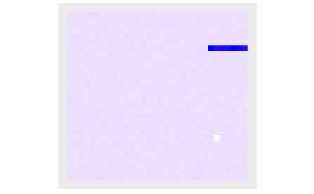

```r
#186 is too high
grdf<-as.data.frame(t(as.data.frame(nodes)))
colnames(grdf)<-c("x","y","size","used","avail","use%")

ggplot(grdf, aes(x, y, fill= used)) +
  geom_tile()+
  scale_fill_gradient(low="white", high="blue") +
  theme(axis.text.x = element_blank(),
        axis.ticks.x = element_blank(),
        axis.text.y = element_blank(),
        axis.ticks.y = element_blank(),
        axis.title.y = element_blank(),
        axis.title.x = element_blank(),
        panel.grid.major = element_blank(),
        panel.grid.minor = element_blank(),
        legend.position="none")+
  scale_y_reverse()+
  coord_fixed()
```

It looks like an empty square in the lower right quadrant, a bunch of numbers that are pretty close, and a “wall” of high numbers between the empty square and the upper right corner.

So, the “path” is to move the empty square up to the upper right corner (around the wall), then the value in the upper right corner to the upper left corner

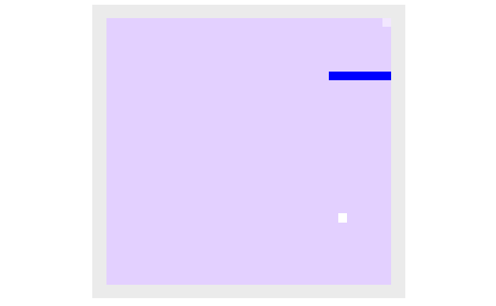

```r
grdf$x<-grdf$x+1
grdf$y<-grdf$y+1
grdf<-grdf %>% mutate(val=round(used,-2))
grdf$val[intersect(which(grdf$x==max(grdf$x)),which(grdf$y==1))]<-50
ggplot(grdf, aes(x, y, fill= val)) +
  geom_tile()+
  scale_fill_gradient(low="white", high="blue") +
  theme(axis.text.x = element_blank(),
        axis.ticks.x = element_blank(),
        axis.text.y = element_blank(),
        axis.ticks.y = element_blank(),
        axis.title.y = element_blank(),
        axis.title.x = element_blank(),
        panel.grid.major = element_blank(),
        panel.grid.minor = element_blank(),
        legend.position="none")+
  scale_y_reverse()+
  coord_fixed()
```

The goal is to get the light purple square in the upper right corner to the upper left corner.

So make this into a matrix

```r
gr<-matrix(0,ncol=max(grdf$x),nrow=max(grdf$y))
for(i in 1:nrow(grdf)){
  gr[grdf$y[i],grdf$x[i]]<-grdf$val[i]}
gr
```

```
      [,1] [,2] [,3] [,4] [,5] [,6] [,7] [,8] [,9] [,10] [,11] [,12] [,13] [,14] [,15] [,16] [,17] [,18] [,19]
 [1,]  100  100  100  100  100  100  100  100  100   100   100   100   100   100   100   100   100   100   100
 [2,]  100  100  100  100  100  100  100  100  100   100   100   100   100   100   100   100   100   100   100
 [3,]  100  100  100  100  100  100  100  100  100   100   100   100   100   100   100   100   100   100   100
 [4,]  100  100  100  100  100  100  100  100  100   100   100   100   100   100   100   100   100   100   100
 [5,]  100  100  100  100  100  100  100  100  100   100   100   100   100   100   100   100   100   100   100
 [6,]  100  100  100  100  100  100  100  100  100   100   100   100   100   100   100   100   100   100   100
 [7,]  100  100  100  100  100  100  100  100  100   100   100   100   100   100   100   100   100   100   100
 [8,]  100  100  100  100  100  100  100  100  100   100   100   100   100   100   100   100   100   100   100
 [9,]  100  100  100  100  100  100  100  100  100   100   100   100   100   100   100   100   100   100   100
[10,]  100  100  100  100  100  100  100  100  100   100   100   100   100   100   100   100   100   100   100
[11,]  100  100  100  100  100  100  100  100  100   100   100   100   100   100   100   100   100   100   100
[12,]  100  100  100  100  100  100  100  100  100   100   100   100   100   100   100   100   100   100   100
[13,]  100  100  100  100  100  100  100  100  100   100   100   100   100   100   100   100   100   100   100
[14,]  100  100  100  100  100  100  100  100  100   100   100   100   100   100   100   100   100   100   100
```

[output cut: 47 more lines]

A quick function to figure out priority - because it’s going to be weird:

```r
gridpri<-function(zx,zy,gx,gy,t){
  #start with time already used
  pri<-t
  # add the distance from the goal square to the top left point
  pri<-pri+(gx-1)+(gy-1)
  ### if the goal has moved
  if(gx==32&&gy==1){
  ### to make sure that the zero gets around the wall -
  ### if it's already higher up, distance betwen the zero point and the goal
    if(zy<=7){pri<-pri+abs(zx-gx)+abs(zy-gy)
  ### if its below, then distance to the wall edge(7,25)+ distance to the goal
    }else{pri<-pri+abs(zx-25)+abs(zy-7)+13}}
pri}
```

The search itself isn’t quite so weird - but just hardcoding in the starting values to make things easier.

```r
 grbfs<-function(g=gr){
   dct<-dict()
   pq<-priority_queue()
   pq$push(list(gr,0))
   while(pq$size()>0){
     curr<-pq$pop()
     currg<-curr[[1]]
     ### if we're done, stop
     if(currg[1,1]==50){return(curr[[2]])
       break}
     ### if we've been here before, next
     if(dct$has(currg)){next}
     dct$set(currg,curr[[2]])
     z<-as.vector(which(currg==0,arr.ind=TRUE))
     goal<-as.vector(which(currg==50,arr.ind=TRUE))
     t<-unlist(curr[[2]])
     ###up
     if(z[1]>1&&g[(z[1]-1),z[2]]<200){
       u<-currg
       u[z[1],z[2]]<-currg[(z[1]-1),z[2]]
       u[(z[1]-1),z[2]]<-0
       ug<-as.vector(which(u==50,arr.ind=TRUE))
       pri<-gridpri(z[2],z[1]-1,ug[2],ug[1],curr[[2]]+1)
       pq$push(list(u,t+1),priority=-pri)}
     ###down
     if(z[1]<30&&g[(z[1]+1),z[2]]<200){
       d<-currg
       d[z[1],z[2]]<-currg[(z[1]+1),z[2]]
       d[(z[1]+1),z[2]]<-0
       dg<-as.vector(which(d==50,arr.ind=TRUE))
       pri<-gridpri(z[2],z[1]-1,dg[2],dg[1],curr[[2]]+1)
       pq$push(list(d,t+1),priority=-pri)}
     ###left
     if(z[2]>1&&g[z[1],(z[2]-1)]<200){
       l<-currg
       l[z[1],z[2]]<-currg[z[1],(z[2]-1)]
       l[z[1],(z[2]-1)]<-0
       lg<-as.vector(which(l==50,arr.ind=TRUE))
       pri<-gridpri(z[2],z[1]-1,lg[2],lg[1],curr[[2]]+1)
       pq$push(list(l,t+1),priority=-pri)}
     ###right
     if(z[2]<32&&g[z[1],(z[2]+1)]<200){
       r<-currg
       r[z[1],z[2]]<-currg[z[1],(z[2]+1)]
       r[z[1],(z[2]+1)]<-0
       rg<-as.vector(which(r==50,arr.ind=TRUE))
       pri<-gridpri(z[2],z[1]+1,rg[2],rg[1],curr[[2]]+1)
       pq$push(list(r,t+1),priority=-pri)}
   }
###
 list(dct,pq)}
```

```r
part2<-grbfs()
part2
```

```
[1] 181
```